# Eigenfunction_Comparisons

## Domain and Problem Setup

We wish to consider the problem $$ -\nabla^2 u = \omega^2 u $$ on our "cross-in-the-plane" geometry, the period cell of which is illustrated below:

[figure not shown]

The full domain consists of $N$ period cells along each axis (for a total of $N^2$ cells), each of size $1\times 1$. Tube widths are taken as $l = \frac{1}{2N}$, whilst the radii of the circles is $r = \sqrt{\frac{l}{\alpha\pi}}$, where $\alpha\in\mathbb{R}$ is (a proxy for) the coupling constant which appears in the singular-structure limit problem.

**NOTE:** This assumes $\alpha \approx \frac{V_{vertex}}{V_{edge}}$ is a good proxy for the $\alpha$ that appears in our singular-stuture (QG) problem, although in all cases this is not the *precise* relation.

**NOTE 2:** In the code files, $l$ is denoted by `h` due to keyword reservations.

We first assemble the two stiffness matrices that we need for the analysis of the spectrum of $$ -\nabla^2 u = \omega^2 u, $$ by writing the weak form of this equation; $$ \int_{\Omega} \nabla u \cdot \nabla \phi - \omega^2 u \phi \ \mathrm{d}x = 0.$$ We denote by $A_1$ and $A_2$ the stiffness matrices for $\int_{\Omega} \nabla u \cdot \nabla \phi \ \mathrm{d}x$ and $\int_{\Omega} u \phi \ \mathrm{d}x$ (respectively) to be assembled and saved.

**NOTE 3:** The $-$ sign is *not* included in the stiffness matrix for $A_2$!

**NOTE 4:** As per `AssembleStiffnessMatrices.py`, the prefactor $-\omega^2$ is not included in $A_2$, so that we can solve the above as a generalised eigenvalue problem using SciPy.

Having computed the eigenvalues for multiple values of $N$, we now want to compare the behaviour of the eigenvalues and corresponding eigenfunctions. This work is not being placed into a script, simply because

1. We don't know what we're going to end up with, hence what to look at
2. We don't know if automation will be possible currently

```python
from fenics import *
from dolfin import *

import numpy as np

import scipy.sparse as spSparse
import scipy.sparse.linalg as spla

import matplotlib.pyplot as plt
from matplotlib import rc
rc('text', usetex=True)

%matplotlib inline

import glob
import subprocess

# This is the name of our mesh files, minus the extension.
filePrefix = 'FEM_CrossGraphSetup'
# This is the gmsh file which generated our domain's mesh. We can infer information about our domain from it
gmshFile = filePrefix + '.geo'
# This is the folder into which we will place our stiffness matrices, once they are assembled
matDumpFolder = 'StiffnessMatrixDump'
evalDumpFolder = 'EvalDump'
meshDumpFolder = 'MeshDump'

# Create a subclass for the 2D-periodic domain...
class PeriodicDomain(SubDomain):
    #map left--> right and bottom-->top

    def inside(self, x, on_boundary):
        # return True if on left or bottom boundary AND NOT on one of the two corners
        return bool((near(x[0], 0) or near(x[1], 0)) and
                (not ((near(x[0], 0) and near(x[1], N)) or
                        (near(x[0], N) and near(x[1], 0)))) and on_boundary)

    def map(self, x, y):
        if near(x[0], N) and near(x[1], N):
            y[0] = x[0] - N
            y[1] = x[1] - N
        elif near(x[0], N):
            y[0] = x[0] - N
            y[1] = x[1]
        else:   # near(x[1], N)
            y[0] = x[0]
            y[1] = x[1] - N
#concludes the SubDomain subclass definition
```

The following functions are useful for handling plotting, and extracting information from files.

```python
def DeduceN(gFile, line=11):
    '''
    Deduce value of N from the .geo file gFile.
    Optionally, provide the index of the line where this definition appears,
    default search will be on line 12 (index 11) as per the established convention.
    '''
    with open('FEM_CrossGraphSetup.geo') as fp:
        for i, line in enumerate(fp):
            if i == 11:
                # 11th line
                Nstr = line[4:-2] #take all characters after the numerical value appears in the file
            elif i > 11:
                #terminate loop early
                break
    # We want N as a float because we will use it in computations, to define points on meshes etc. Int might cause bugs.
    for i, char in enumerate(Nstr):
        if char==';':
            Nstr = Nstr[:i]
            break
    N = float(Nstr)
    return N, Nstr

def FigWindowSettings(axis):
    '''
    Changes a matplotlib.pyplot axis object to have no top and right border or tick marks.
    INPUTS:
        axis: matplotlib.pyplot axis object
    '''

    # Hide the right and top spines
    axis.spines['right'].set_visible(False)
    axis.spines['top'].set_visible(False)
    # Only show ticks on the left and bottom spines
    axis.yaxis.set_ticks_position('left')
    axis.xaxis.set_ticks_position('bottom')
    return

def PlotFunction(N, u, w):

    # Mesh files are saved in the meshDumpFolder with the naming convention
    # Mesh-Nx.xml, where x is replaced by the parameter value of N.
    meshFile = './' + meshDumpFolder + '/Mesh-N' + str(N) + '.xml'
    mesh = Mesh(meshFile)
    print('Loaded meshfile %s' % (meshFile))

    V = FunctionSpace(mesh, 'CG', 1, constrained_domain=PeriodicDomain())
    U = Function(V)
    U.vector()[:] = u

    fig, ax = plt.subplots(1)
    FigWindowSettings(ax)
    plot(U)
    fig.colorbar(plot(U))
    ax.set_xlabel(r'$x$')
    ax.set_ylabel(r'$y$')
    ax.set_title(r'$N = %d, \ \omega= %.5f $' % (N, w))

    return fig, ax
```

We now begin to import any data (eigenvalues and eigenvectors) that we have determined and saved to the relevant folders. It may be the case that there are multiple files for a given value of $N$, depending on whether or not we computed a greater number of eigenvalues and eigenvectors in a given run. As a temporary default, we will always import the data from the file that contains the *greatest* number of eigenvalues.

Filenames are stored under the convention

- `evals-Nxx-yyy.npy` for eigenvalues, where `xx` is replaced by the value of $N$ used in that run, and `yyy` is the number of eigenvalues computed.
- `evecs-Nxx-yyy.npy` for eigenvectors, with the same meanings of `xx` and `yyy` as above. From this, we can always infer how many eigenvalues (and vectors) we are going to import from each file, so can get python to import the correct file.

The outputs are saved to a `dict` called `files`, whose keys are the parameter values of $N$. Each field is then a list of three objects, `[nEvals, wVals, wVecs]` where `nEvals` is the number of eigenvalues for that value of $N$ (IE, that key), and `wVals` and `wVecs` are numpy arrays storing the eigenvalues and eigenvectors, respectively.

```python
# Infer filenames storing evals and evecs, as stored in evalDumpFolder
# Each of these files has a name of the form
# evals-Nxx-yyy.npy,
# were xx is replaced by the value of N used, and yyy is the number of e'values the file stores.
# For each value of N, there may be multiple files with eigenvalues, so we want to look at the largest value
# of yyy for each xx.
preAppend = './' + evalDumpFolder + '/evals-'
evalFileMatches = glob.glob(preAppend + '*.npy')
# This is a list of all the candidate files, which we have generated that contain eigenvalues and eigenvectors

params = []
for filename in evalFileMatches:
    breaks = filename.split('-')[1:]
    # this splits filenames by '-', which should break each filename into 3 parts
    # the first is just preAppend, which we can discard using the [1:] syntax
    # the second part is 'Nxx', and the third is 'yyy.npy', which we can now convert to ints
    breaks[0] = int( breaks[0][1:] )
    # discard the N in 'Nxx', and convert the value to an integer
    breaks[1] = int( breaks[1][:-4])
    # discard the '.npy' in 'yyy.npy' and convert the value to an integer
    params.append(breaks)

# params now contains [N, nEvals, i] for each file in evalFileMatches, where i is the index of the file in which
# the parameters N and nEvals were used.
# Now, for each unique N, we find the largest such nEvals, and use THAT file.
params = np.asarray(params)
params = params[params[:,0].argsort()] # sorts the values in params by the 1st column, IE by the value N
Ns = np.unique(params[:,0]) # get the unique values of N
# Create a dictionary, with keys equal to the values of N.
# Each field is then a list [nEvals, wVals, wVecs] of the loaded information
files = {}
for n in Ns:
    # Get the sub-matrix of params that corresponds to this particular value of N
    posNEvals = params[params[:,0]==n]
    # Now sort this sub-matrix by column 1, IE value of nEvals
    posNEvals = posNEvals[posNEvals[:,1].argsort()]
    # This means that the max. value of nEvals is stored at the bottom of this array, so
    # we know the value of N and nEvals to use, and thus the file to import.
    nEvals = posNEvals[-1,1]
    wVals = np.load(preAppend + 'N' + str(n) + '-' + str(nEvals) + '.npy')
    wVecs = np.load('./' + evalDumpFolder + '/evecs-' + 'N' + str(n) + '-' + str(nEvals) + '.npy')
    files[n] = [nEvals, wVals, wVecs]
    print('Deduced for N=%d, nEvals=%d should be used' % (n, nEvals))
```

```
Deduced for N=3, nEvals=286 should be used
Deduced for N=4, nEvals=604 should be used
Deduced for N=5, nEvals=1047 should be used
Deduced for N=6, nEvals=1782 should be used
Deduced for N=7, nEvals=2901 should be used
Deduced for N=8, nEvals=2196 should be used
Deduced for N=9, nEvals=2922 should be used
Deduced for N=10, nEvals=2159 should be used
Deduced for N=11, nEvals=2681 should be used
Deduced for N=12, nEvals=3710 should be used
```

### Quick eigenvalue distribution plots

Next, let's get a brief look at the distribution of eigenvalues across the values of $N$. We can use a simple scatter plot to see if there is any prevailent "band-gap" structure, and whether we can identify the "first band".

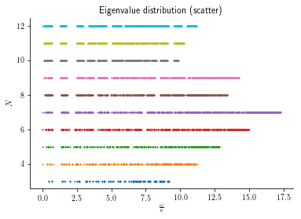

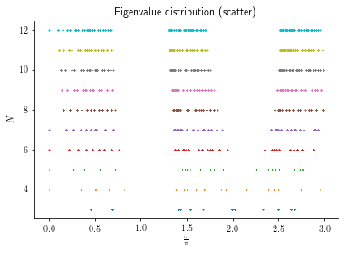

```python
# Now we have all the eigenvalues imported, we can plot each spectrum on the same graph
# to see how the eigenvalues change as N increases

# First, a scatter plot of the whole spectrum...
fig, ax = plt.subplots(1)
FigWindowSettings(ax)
for key in files.keys():
    wVals = files[key][1]
    ax.scatter(wVals / np.pi, key * np.ones_like(wVals), label = str(key), marker='x', s=1)
ax.set_xlabel(r'$\frac{\omega}{\pi}$')
ax.set_ylabel(r'$N$')
ax.set_title(r'Eigenvalue distribution (scatter)')
fig.show()

# The above figure might appear quite crowded in places due to the density of eigenvalues,
# so let's "zoom in" on the first few bands

# Note: this cut-off value is set manually, so will need to change depending on the geometry!
fig, ax = plt.subplots(1)
FigWindowSettings(ax)
wCutOff = 3.0 * np.pi
for key in files.keys():
    wVals = files[key][1]
    ax.scatter(wVals[wVals <= wCutOff] / np.pi, key * np.ones_like(wVals[wVals <= wCutOff]), \
               label = str(key), marker='x', s=1)
ax.set_xlabel(r'$\frac{\omega}{\pi}$')
ax.set_ylabel(r'$N$')
ax.set_title(r'Eigenvalue distribution (scatter)')
fig.show()
```

We might also find it useful to plot the counting function for each value of $N$ too. This is just the function $$f_{N}(x) = \# \{ \omega\in\sigma(N) \ \vert \ \omega <= x \}$$ where $\omega\in\sigma(N)$ is the set of computed eigenvalues at the parameter value $N$. The hashtag denotes the count of the number of elements.

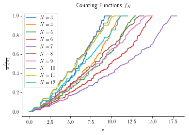

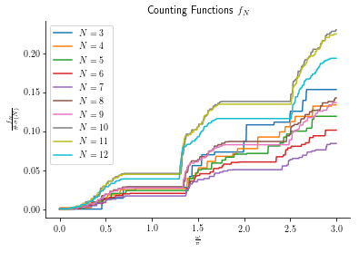

```python
def CountingFunction(x, wVals):
    '''
    Given the eigenvalues stored in wVals, return the value of the counting function at x, as defined above.
    INPUTS:
        x: float or numpy-float array - values of x to evaluate the counting function at
    '''

    if (type(x)==float or type(x)==int):
        fx = np.shape(wVals[wVals <= x])[0]
    else:
        fx = np.zeros_like(x, dtype=int)
        for i, xi in enumerate(x):
            fx[i] = np.shape(wVals[wVals <= xi])[0]
    return fx

# Now we can plot the counting functions on the same axis to compare behaviours
# Higher values of N lead to more eigenvalues being computed though, so we "normalise" by nEvals for each value of N
ptsPerPi = 250 #use this many interpolation points per range of pi
fig, ax = plt.subplots(1)
FigWindowSettings(ax)
for key in files.keys():
    wVals = files[key][1] / np.pi #normalise beforehand
    nPis = np.ceil(np.max(wVals)) #number of multiples of pi, rounded up
    wPts = np.linspace(0, nPis, nPis*ptsPerPi) #get range for plotting counting function
    # compute value of counting function at each point in the range, then normalise by nEvals
    fN = CountingFunction(wPts, wVals) / files[key][0]
    ax.plot(wPts, fN, label = r'$N=' + str(key) + '$')
ax.set_xlabel(r'$\frac{\omega}{\pi}$')
ax.set_ylabel(r'$\frac{f_{N}}{\#\sigma(N)}$')
ax.set_title(r'Counting Functions $f_N$')
ax.legend()
fig.show()

# The above figure might appear quite crowded in places due to the density of eigenvalues,
# so let's "zoom in" on the first few bands

# Note: this cut-off value is set manually, so will need to change depending on the geometry!
ptsPerPi = 250
wCutOff = 3.0 * np.pi
fig, ax = plt.subplots(1)
FigWindowSettings(ax)
for key in files.keys():
    wVals = files[key][1]
    wVals = wVals[wVals <= wCutOff] / np.pi
    nPis = np.ceil(np.max(wVals))
    wPts = np.linspace(0, nPis, nPis*ptsPerPi)
    fN = CountingFunction(wPts, wVals) / files[key][0]
    ax.plot(wPts, fN, label = r'$N=' + str(key) + '$')
ax.set_xlabel(r'$\frac{\omega}{\pi}$')
ax.set_ylabel(r'$\frac{f_{N}}{\#\sigma(N)}$')
ax.set_title(r'Counting Functions $f_N$')
ax.legend()
fig.show()
```

### Eigenfunctions at the "right edge" of the first band

We are thus interested in the behaviour of the eigenfunctions that appear to be "shrinking" to this single value of 0, and so we would like to plot them. From the plots above, it appears that all the eigenvalues found in the first-band are less than $\pi$, and so we can extract and plot them knowing this. In particular, for each $N$ we can plot the eigenfunction corresponding to the eigenvalue "furthest to the right" (IE the greatest) in the first band.

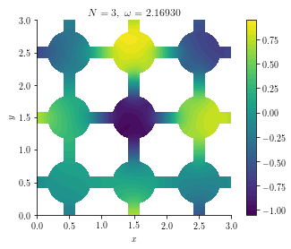

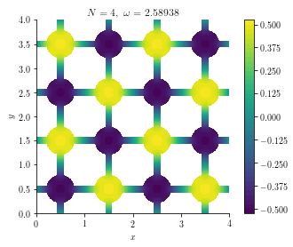

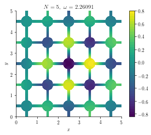

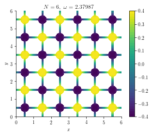

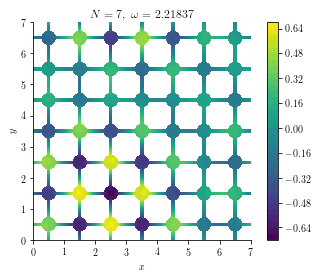

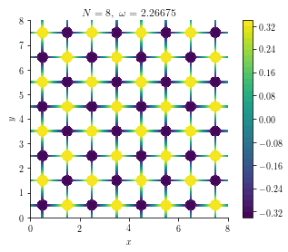

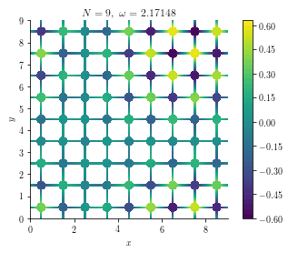

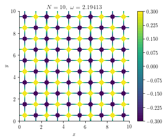

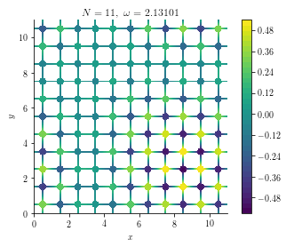

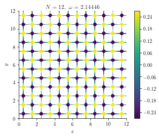

```python
# This is the value of omega for which we are going to use as an upper limit for the first band
wBandCap = np.pi
wValsPlotted = []
for N in files.keys():
    wVals = files[N][1]
    wVecs = files[N][2]
    wIndex = np.where(wVals <= wBandCap)[0] #get last value in array of eigenvalues less than the cut off
    w = wVals[wIndex[-1]]
    wValsPlotted.append(w)
    u = wVecs[:, wIndex[-1]]
    fig, ax = PlotFunction(N, u, w)
    fig.show()
```

There appears to be a marked difference between the "right-most" eigenfunctions for even valued $N$ compared to those for odd-valued $N$. That is to say, the eigenfunctions for odd-valued $N$ appear to "localise" themselves in one portion of the domain, and are almost zero everywhere else. By contrast, the eigenfunctions for even-valued $N$ look like they vary periodically and rapidly (albeit with an amplitude decreasing as $N\rightarrow\infty$) across the entire domain.

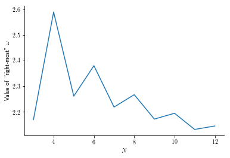

```python
# Also worth considering is whether the eigenvalues we found at the "end" of the bands were descending in value...
fig, ax = plt.subplots(1)
FigWindowSettings(ax)
ax.plot(np.array(list(files.keys())), wValsPlotted)
ax.set_xlabel(r'$N$')
ax.set_ylabel(r'Value of ``right-most" $\omega$')
fig.show()
```